# Introduction

This notebook will cover all basic elements of using OSMnx and Networkx for road network analysis, such as:

- extracting basic statistics
- understanding node and edge characteristics of road networks
- identifying and visualizing shortest paths on folium

```python
import networkx as nx
import osmnx as osx
import pandas as pd
import geopandas as gpd
from shapely.geometry import Point,Polygon,LineString
import matplotlib.pyplot as plt
import folium
```

## Plot Graph

OSMnx provides ways to query graphs from specific locations. `graph_from_point` allows us to specify a latitude and longitude (in that order) as a center point from which it returns the network within a certain distance.

You can specify what types of streets to extract by passing a string to `network_type`. These options include the following:

- `drive` – get drivable public streets (but not service roads)
- `drive_service` – get drivable public streets, including service roads
- `walk` – get all streets and paths that pedestrians can use (this network type ignores one-way directionality)
- `bike` – get all streets and paths that cyclists can use
- `all` – download all (non-private) OSM streets and paths
- `all_private` – download all OSM streets and paths, including private-access ones

The example below is a graph of the Legaspi Village area of Makati City.

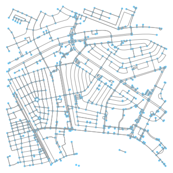

```python
lat = 14.556198
long = 121.017161

graph = osx.graph_from_point((lat, long), distance=1000,
                             network_type='drive_service',
                             retain_all=True)
plot = osx.plot_graph(graph)
```

## Setting the coordinate reference system

```python
graph = osx.project_graph(graph, to_crs={'init': 'epsg:32651'})
```

## Analyze Network

`osx.basic_stats` will return all summary statistics for the graph.

```python
stats = osx.basic_stats(graph)
stats
```

```
{'n': 906,
 'm': 1784,
 'k_avg': 3.938189845474614,
 'intersection_count': 776,
 'streets_per_node_avg': 2.9403973509933774,
 'streets_per_node_counts': {0: 0, 1: 130, 2: 13, 3: 555, 4: 198, 5: 9, 6: 1},
 'streets_per_node_proportion': {0: 0.0,
  1: 0.1434878587196468,
  2: 0.01434878587196468,
  3: 0.6125827814569537,
  4: 0.2185430463576159,
  5: 0.009933774834437087,
  6: 0.0011037527593818985},
 'edge_length_total': 114741.8439999999,
 'edge_length_avg': 64.31717713004478,
 'street_length_total': 86500.7839999999,
 'street_length_avg': 67.52598282591717,
 'street_segments_count': 1281,
 'node_density_km': None,
 'intersection_density_km': None,
 'edge_density_km': None,
 'street_density_km': None,
 'circuity_avg': 1.3583667122132007e-05,
 'self_loop_proportion': 0.0011210762331838565,
 'clean_intersection_count': None,
 'clean_intersection_density_km': None}
```

## Calculate the coverage area of street network

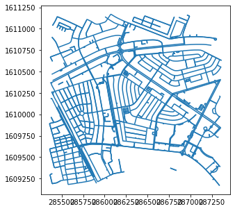

```python
edges = osx.graph_to_gdfs(graph, nodes=False, edges=True)
edges.plot(figsize=(10,5))
```

- `unary_union` combines all edges
- `convex_hull` creates a bounding polygon
- `area` computes area inside this polygon

```python
area = edges.unary_union.convex_hull.area
area
```

```
3879473.767149186
```

If you want a more detailed view of the summary stats, the code below will provide it.

```python
# retrieve missing stats using area
stats = osx.basic_stats(graph, area=area)
stats
```

```
{'n': 906,
 'm': 1784,
 'k_avg': 3.938189845474614,
 'intersection_count': 776,
 'streets_per_node_avg': 2.9403973509933774,
 'streets_per_node_counts': {0: 0, 1: 130, 2: 13, 3: 555, 4: 198, 5: 9, 6: 1},
 'streets_per_node_proportion': {0: 0.0,
  1: 0.1434878587196468,
  2: 0.01434878587196468,
  3: 0.6125827814569537,
  4: 0.2185430463576159,
  5: 0.009933774834437087,
  6: 0.0011037527593818985},
 'edge_length_total': 114741.8439999999,
 'edge_length_avg': 64.31717713004478,
 'street_length_total': 86500.7839999999,
 'street_length_avg': 67.52598282591717,
 'street_segments_count': 1281,
 'node_density_km': 233.53682854408626,
 'intersection_density_km': 200.02712908411803,
 'edge_density_km': 29576.65159940427,
 'street_density_km': 22297.040576089425,
 'circuity_avg': 1.3583667122132007e-05,
 'self_loop_proportion': 0.0011210762331838565,
 'clean_intersection_count': None,
 'clean_intersection_density_km': None}
```

```python
# this is a lot of stuff. Gives info per node
stats_x = osx.extended_stats(graph, ecc=False, bc=True, cc=True)
```

```python
# Convert this into something more readable:
for key, value in stats_x.items():
    stats[key] = value
pd.Series(stats)
```

```
n                                                                                    906
m                                                                                   1784
k_avg                                                                            3.93819
intersection_count                                                                   776
streets_per_node_avg                                                              2.9404
streets_per_node_counts                {0: 0, 1: 130, 2: 13, 3: 555, 4: 198, 5: 9, 6: 1}
streets_per_node_proportion            {0: 0.0, 1: 0.1434878587196468, 2: 0.014348785...
edge_length_total                                                                 114742
edge_length_avg                                                                  64.3172
street_length_total                                                              86500.8
street_length_avg                                                                 67.526
street_segments_count                                                               1281
node_density_km                                                                  233.537
intersection_density_km                                                          200.027
edge_density_km                                                                  29576.7
street_density_km                                                                  22297
circuity_avg                                                                 1.35837e-05
self_loop_proportion                                                          0.00112108
clean_intersection_count                                                            None
clean_intersection_density_km                                                       None
avg_neighbor_degree                    {12072839: 1.5, 12072844: 2.3333333333333335, ...
avg_neighbor_degree_avg                                                          2.08352
avg_weighted_neighbor_degree           {12072839: 0.028504646257339946, 12072844: 0.0...
avg_weighted_neighbor_degree_avg                                                0.067485
degree_centrality                      {12072839: 0.004419889502762431, 12072844: 0.0...
degree_centrality_avg                                                         0.00435159
clustering_coefficient                 {12072839: 0.16666666666666666, 12072844: 0, 1...
clustering_coefficient_avg                                                     0.0480868
clustering_coefficient_weighted        {12072839: 0.00697118373785828, 12072844: 0, 1...
clustering_coefficient_weighted_avg                                           0.00203703
pagerank                               {12072839: 0.0011726006534939482, 12072844: 0....
pagerank_max_node                                                              305572145
pagerank_max                                                                  0.00482311
pagerank_min_node                                                              303810100
pagerank_min                                                                 0.000175417
closeness_centrality                   {12072839: 0.0005687307616043709, 12072844: 0....
closeness_centrality_avg                                                     0.000590097
betweenness_centrality                 {12072839: 0.007794700044003325, 12072844: 0.0...
betweenness_centrality_avg                                                      0.022789
dtype: object
```

# Shortest Path Analysis

OSMnx provides ways to generate paths along the road network. Shortest path analysis is a common use case for any basic road network analysis.

```python
# Set origin and destination
origin = 121.018725, 14.552500
dest = 121.013996, 14.558430
dest2 = 121.024707, 14.560552
```

`graph_to_gdfs` allows us to generate `GeoDataFrame` objects of the nodes (turns and intersections) and edges (roads). This allows us to view the features available.

```python
nodes, edges = osx.graph_to_gdfs(graph, nodes=True, edges=True)
```

```python
nodes.head()
```

|  | y | x | osmid | highway | lon | lat | geometry |
| --- | --- | --- | --- | --- | --- | --- | --- |
| 12072839 | 1.609839e+06 | 287336.945643 | 12072839 | traffic_signals | 121.026258 | 14.553282 | POINT (287336.946 1609838.660) |
| 12072844 | 1.610241e+06 | 286791.230967 | 12072844 | traffic_signals | 121.021163 | 14.556877 | POINT (286791.231 1610241.271) |
| 12072856 | 1.610538e+06 | 287169.518512 | 12072856 | NaN | 121.024649 | 14.559590 | POINT (287169.519 1610538.172) |
| 12072858 | 1.610582e+06 | 287156.793120 | 12072858 | NaN | 121.024527 | 14.559987 | POINT (287156.793 1610582.195) |
| 12072892 | 1.609526e+06 | 286952.865277 | 12072892 | NaN | 121.022721 | 14.550426 | POINT (286952.865 1609525.926) |

Roads have attributes depending on data availability. More information about these features can be found here: https://wiki.openstreetmap.org/wiki/Key:highway

```python
edges.head()
```

|  | u | v | key | osmid | oneway | lanes | name | highway | length | geometry | maxspeed | service | junction | bridge | access | ref | tunnel |
| --- | --- | --- | --- | --- | --- | --- | --- | --- | --- | --- | --- | --- | --- | --- | --- | --- | --- |
| 0 | 12072839 | 360289808 | 0 | 700702822 | True | 4 | Ayala Avenue | secondary | 11.039 | LINESTRING (287336.946 1609838.660, 287345.411... | NaN | NaN | NaN | NaN | NaN | NaN | NaN |
| 1 | 12072839 | 243486951 | 0 | [32090457, 712417491] | True | 2 | Parkway Drive | unclassified | 94.207 | LINESTRING (287336.946 1609838.660, 287283.216... | NaN | NaN | NaN | NaN | NaN | NaN | NaN |
| 2 | 12072844 | 316974315 | 0 | 40260140 | True | 2 | Paseo de Roxas | secondary | 17.679 | LINESTRING (286791.231 1610241.271, 286781.403... | NaN | NaN | NaN | NaN | NaN | NaN | NaN |
| 3 | 12072844 | 371022096 | 0 | 132684522 | False | 4 | Ayala Avenue | secondary | 16.049 | LINESTRING (286791.231 1610241.271, 286804.650... | NaN | NaN | NaN | NaN | NaN | NaN | NaN |
| 4 | 12072844 | 225266054 | 0 | [132684528, 701096365, 701644606, 701644607] | True | [4, 5] | Ayala Avenue | secondary | 296.247 | LINESTRING (286791.231 1610241.271, 286777.394... | NaN | NaN | NaN | NaN | NaN | NaN | NaN |

```python
# find boundaries in gdf
max_x = nodes['x'].max()
min_x = nodes['x'].min()
max_x, min_x
```

```
(287363.1568399588, 285357.20192804217)
```

We need the `Point` object for later operations, so it might be useful to represent our origin and destination in a GeoDataFrame for easier reference.

What's important here is that we extract the geometry of each point.

```python
# Get geometry
gdf = gpd.GeoDataFrame([{"geometry": Point(origin)},
                        {"geometry": Point(dest2)}],
                       crs={'init':'epsg:4326'})
gdf.to_crs({'init': 'epsg:32651'}, inplace=True)
origin_point = gdf.loc[0].geometry
dest_point = gdf.loc[1].geometry

gdf
```

|  | geometry |
| --- | --- |
| 0 | POINT (286524.204 1609759.159) |
| 1 | POINT (287176.693 1610644.582) |

`get_nearest_node` returns the node closest to the coordinates given, since our origin and destination will not always be exactly on a node. `return_dist` returns a tuple containing the node ID and its distance from the selected point.

```python
O = osx.get_nearest_node(graph, (origin_point.y, origin_point.x),
                         method='euclidean', return_dist=True)
D = osx.get_nearest_node(graph, (dest_point.y, dest_point.x),
                         method='euclidean', return_dist=True)
```

```python
O, D
```

```
((242537959, 41.14391003197797), (33441984, 60.11236121488976))
```

Networkx has a `shortest_path` function which returns the nodes along the shortest path between two nodes.

```python
path = nx.shortest_path(G=graph, source=O[0], target=D[0])
path
```

```
[242537959,
 242537730,
 243510157,
 243510158,
 243490615,
 5883244879,
 2597472271,
 5880236726,
 243490620,
 242417471,
 242417487,
 27049502,
 304180447,
 225266054,
 178163400,
 266528794,
 6627397390,
 33441824,
 33441780,
 178154454,
 178156901,
 207011738,
 207011682,
 207011703,
 207011719,
 33441984]
```

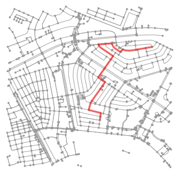

```python
fig, ax = osx.plot_graph_route(graph, path, origin_point=origin,
                               destination_point=dest)
```

```python
# Extract node information along shortest path

route_nodes = nodes.loc[path]
route_nodes.head(3)
```

|  | y | x | osmid | highway | lon | lat | geometry |
| --- | --- | --- | --- | --- | --- | --- | --- |
| 242537959 | 1.609751e+06 | 286483.789702 | 242537959 | NaN | 121.018351 | 14.552427 | POINT (286483.790 1609751.443) |
| 242537730 | 1.609799e+06 | 286489.966483 | 242537730 | NaN | 121.018404 | 14.552854 | POINT (286489.966 1609798.589) |
| 243510157 | 1.609843e+06 | 286495.786130 | 243510157 | NaN | 121.018455 | 14.553256 | POINT (286495.786 1609843.093) |

```python
# # extract line from the nodes
# route_line = LineString(list(route_nodes.geometry.values))
# route_line
```

# Plotting on Folium

```python
path_edges = []
adj = graph.adj
for i in range(0,len(path)-1):
    edges = adj[path[i]][path[i+1]]
    min_length = float("inf")
    min_edge = None
    for key in edges:
        edge = edges[key]
        if edge["length"] < min_length:
            min_length = edge["length"]
            min_edge = edge
    path_edges.append((path[i],path[i+1],min_edge))
path_edges
```

```
[(242537959,
  242537730,
  {'osmid': [704471784, 704471785, 671307925],
   'oneway': True,
   'lanes': '3',
   'name': 'Trasierra',
   'highway': 'unclassified',
   'length': 47.772,
   'geometry': <shapely.geometry.linestring.LineString at 0x7f7160df7550>}),
 (242537730,
  243510157,
  {'osmid': [704471781, 704471786, 658325613],
   'oneway': True,
   'lanes': '3',
   'name': 'Trasierra',
   'highway': 'unclassified',
   'length': 45.095,
   'geometry': <shapely.geometry.linestring.LineString at 0x7f7160df7490>}),
 (243510157,
  243510158,
  {'osmid': [654885053, 750019358, 761311711],
   'oneway': True,
   'lanes': '3',
   'name': 'Gamboa',
   'highway': 'tertiary',
   'length': 151.548,
   'geometry': <shapely.geometry.linestring.LineString at 0x7f7160dfe910>}),
 (243510158,
  243490615,
  {'osmid': [703998729, 22598092],
   'oneway': True,
   'lanes': '4',
   'name': 'Rada',
   'highway': 'tertiary',
   'length': 93.33800000000001,
   'geometry': <shapely.geometry.linestring.LineString at 0x7f7160dfe8d0>}),
 (243490615,
  5883244879,
  {'osmid': 704341115,
   'oneway': True,
```

[output cut: 164 more lines]

```
   'oneway': True,
   'lanes': '2',
   'name': 'Tordesillas',
   'highway': 'tertiary',
   'length': 99.78699999999999,
   'geometry': <shapely.geometry.linestring.LineString at 0x7f7160debf10>}),
 (207011719,
  33441984,
  {'osmid': 97081380,
   'oneway': True,
   'lanes': '2',
   'name': 'Tordesillas',
   'highway': 'tertiary',
   'length': 82.36,
   'geometry': <shapely.geometry.linestring.LineString at 0x7f7160debe10>})]
```

```python
path_edges[0]
```

```
(242537959,
 242537730,
 {'osmid': [704471784, 704471785, 671307925],
  'oneway': True,
  'lanes': '3',
  'name': 'Trasierra',
  'highway': 'unclassified',
  'length': 47.772,
  'geometry': <shapely.geometry.linestring.LineString at 0x7f7160df7550>})
```

```python
path_edges[0][2]['length']
```

```
47.772
```

```python
node_dict = dict(graph.nodes)
gdf_builder = []
for edge in path_edges:
    u = node_dict[edge[0]]
    v = node_dict[edge[1]]
    curr = edge[2]
    if "geometry" not in curr:
        geom = LineString([(u['x'],u['y']),(v['x'],v['y'])])
    else:
        geom = curr['geometry']
    res = {"source": edge[0], "target": edge[1],
           "distance": edge[2]['length'], "geometry":geom}
    gdf_builder.append(res)
path_gdf = gpd.GeoDataFrame(gdf_builder,crs={'init':'epsg:32651'})
path_gdf.to_crs({'init':'epsg:4326'},inplace=True)

path_gdf
```

|  | source | target | distance | geometry |
| --- | --- | --- | --- | --- |
| 0 | 242537959 | 242537730 | 47.772 | LINESTRING (121.01835 14.55243, 121.01838 14.5... |
| 1 | 242537730 | 243510157 | 45.095 | LINESTRING (121.01840 14.55285, 121.01843 14.5... |
| 2 | 243510157 | 243510158 | 151.548 | LINESTRING (121.01845 14.55326, 121.01809 14.5... |
| 3 | 243510158 | 243490615 | 93.338 | LINESTRING (121.01709 14.55357, 121.01710 14.5... |
| 4 | 243490615 | 5883244879 | 29.024 | LINESTRING (121.01731 14.55438, 121.01735 14.5... |
| 5 | 5883244879 | 2597472271 | 183.820 | LINESTRING (121.01744 14.55461, 121.01786 14.5... |
| 6 | 2597472271 | 5880236726 | 42.823 | LINESTRING (121.01839 14.55598, 121.01861 14.5... |
| 7 | 5880236726 | 243490620 | 58.605 | LINESTRING (121.01861 14.55631, 121.01867 14.5... |
| 8 | 243490620 | 242417471 | 33.893 | LINESTRING (121.01891 14.55675, 121.01873 14.5... |
| 9 | 242417471 | 242417487 | 19.600 | LINESTRING (121.01864 14.55692, 121.01849 14.5... |
| 10 | 242417487 | 27049502 | 49.445 | LINESTRING (121.01849 14.55702, 121.01834 14.5... |
| 11 | 27049502 | 304180447 | 129.554 | LINESTRING (121.01811 14.55727, 121.01828 14.5... |
| 12 | 304180447 | 225266054 | 17.035 | LINESTRING (121.01879 14.55823, 121.01888 14.5... |
| 13 | 225266054 | 178163400 | 126.807 | LINESTRING (121.01888 14.55836, 121.01906 14.5... |
| 14 | 178163400 | 266528794 | 49.628 | LINESTRING (121.01953 14.55931, 121.01955 14.5... |
| 15 | 266528794 | 6627397390 | 227.448 | LINESTRING (121.01979 14.55968, 121.01975 14.5... |
| 16 | 6627397390 | 33441824 | 6.796 | LINESTRING (121.01813 14.56093, 121.01812 14.5... |
| 17 | 33441824 | 33441780 | 86.236 | LINESTRING (121.01811 14.56098, 121.01891 14.5... |
| 18 | 33441780 | 178154454 | 80.914 | LINESTRING (121.01891 14.56105, 121.01965 14.5... |
| 19 | 178154454 | 178156901 | 156.476 | LINESTRING (121.01965 14.56112, 121.01966 14.5... |
| 20 | 178156901 | 207011738 | 42.833 | LINESTRING (121.02062 14.56015, 121.02081 14.5... |
| 21 | 207011738 | 207011682 | 165.170 | LINESTRING (121.02085 14.56046, 121.02103 14.5... |
| 22 | 207011682 | 207011703 | 20.328 | LINESTRING (121.02235 14.56042, 121.02253 14.5... |
| 23 | 207011703 | 207011719 | 99.787 | LINESTRING (121.02253 14.56045, 121.02261 14.5... |
| 24 | 207011719 | 33441984 | 82.360 | LINESTRING (121.02344 14.56062, 121.02390 14.5... |

```python
# path_gdf
```

```python
curr_map = folium.Map(location = [14.556198, 121.017161], zoom_start = 16)
geojson = path_gdf.to_json()
path = folium.features.GeoJson(geojson)
path.add_to(curr_map)
curr_map
```

[interactive chart not shown]

Below is sample code putting all we've learned together in functions.

```python
def shortest_distance(graph, origin, o_c, dest, dest_c):
    """
    Creates a GeoDataFrame containing the edges of the shortest path
    from an origin to a destination point. These edges are represented
    as linestrings that can be plotted on a map (folium works)

    Also prints the distance of the computed path.

    Parameters
    ----------
    graph : Graph
        osmnx graph of the area containing the points

    origin : str
        name of origin point

    o_c : tuple of floats
        coordinates of origin point in Long/Lat format

    dest : str
        name of destination point

    dest_c : tuple of floats
        coordinates of destination point in Long/Lat format

    Returns
    -------
    path gdf : GeoDataFrame

    shorte
    """
    gdf = gpd.GeoDataFrame([{"name": origin, "geometry": Point(o_c)},
                            {"name": dest, "geometry": Point(dest_c)}],
                           crs={'init':'epsg:4326'})
    gdf.to_crs({'init': 'epsg:32651'}, inplace=True)
    origin_point = gdf.loc[0].geometry
    dest_point = gdf.loc[1].geometry

    O = osx.get_nearest_node(graph, (origin_point.y, origin_point.x),
                             method='euclidean', return_dist=True)
    D = osx.get_nearest_node(graph, (dest_point.y, dest_point.x),
                             method='euclidean', return_dist=True)
    display(gdf)
    path = nx.shortest_path(graph, source=O[0], target=D[0])
    path_edges = []
    adj = graph.adj
    for i in range(0,len(path)-1):
        edges = adj[path[i]][path[i+1]]
        min_length = float("inf")
        min_edge = None
        for key in edges:
            edge = edges[key]
            if edge["length"] < min_length:
                min_length = edge["length"]
                min_edge = edge
        path_edges.append((path[i],path[i+1],min_edge))
    node_dict = dict(graph.nodes)

    gdf_builder = []
    for edge in path_edges:
        u = node_dict[edge[0]]
        v = node_dict[edge[1]]
        curr = edge[2]
        if "geometry" not in curr:
            geom = LineString([(u['x'],u['y']),(v['x'],v['y'])])
        else:
            geom = curr['geometry']
        res = {"source": edge[0], "target": edge[1],
           "distance": edge[2]['length'],"geometry":geom}
        gdf_builder.append(res)
    path_gdf = gpd.GeoDataFrame(gdf_builder,crs={'init':'epsg:32651'})
    path_gdf.to_crs({'init':'epsg:4326'},inplace=True)
    path_gdf

    shortest_dist = path_gdf['distance'].sum()
    print('distance:', shortest_dist)

    # compute shortest path
#     best_path = nx.shortest_path_length(graph, Point(o_c), Point(dest_c))
    return path_gdf, shortest_dist
```

```python
aim = 121.018725, 14.552500
flats = 121.013996, 14.558430
mendo = 121.024707, 14.560552

path_flats, d_x = shortest_distance(graph, 'aim', aim, 'flats', flats)
path_mendo, d_y = shortest_distance(graph, 'aim', aim, 'mendokoro ramen', mendo)
```

|  | name | geometry |
| --- | --- | --- |
| 0 | aim | POINT (286524.204 1609759.159) |
| 1 | flats | POINT (286020.209 1610419.801) |

```
distance: 1507.3709999999999
```

|  | name | geometry |
| --- | --- | --- |
| 0 | aim | POINT (286524.204 1609759.159) |
| 1 | mendokoro ramen | POINT (287176.693 1610644.582) |

```
distance: 2046.3349999999998
```

```python
path_flats
```

|  | source | target | distance | geometry |
| --- | --- | --- | --- | --- |
| 0 | 242537959 | 242537960 | 247.830 | LINESTRING (121.01835 14.55243, 121.01827 14.5... |
| 1 | 242537960 | 242537984 | 56.750 | LINESTRING (121.01608 14.55279, 121.01615 14.5... |
| 2 | 242537984 | 242537377 | 52.634 | LINESTRING (121.01615 14.55228, 121.01620 14.5... |
| 3 | 242537377 | 3729380455 | 97.391 | LINESTRING (121.01621 14.55181, 121.01711 14.5... |
| 4 | 3729380455 | 3729380452 | 59.474 | LINESTRING (121.01711 14.55171, 121.01706 14.5... |
| 5 | 3729380452 | 6688502277 | 5.000 | LINESTRING (121.01706 14.55118, 121.01701 14.5... |
| 6 | 6688502277 | 6687031939 | 125.299 | LINESTRING (121.01701 14.55118, 121.01626 14.5... |
| 7 | 6687031939 | 5291714839 | 48.553 | LINESTRING (121.01585 14.55130, 121.01580 14.5... |
| 8 | 5291714839 | 6615824143 | 237.022 | LINESTRING (121.01550 14.55155, 121.01537 14.5... |
| 9 | 6615824143 | 313868252 | 43.764 | LINESTRING (121.01510 14.55364, 121.01504 14.5... |
| 10 | 313868252 | 313868365 | 137.793 | LINESTRING (121.01499 14.55402, 121.01476 14.5... |
| 11 | 313868365 | 5489173026 | 378.364 | LINESTRING (121.01476 14.55524, 121.01474 14.5... |
| 12 | 5489173026 | 3909460106 | 7.127 | LINESTRING (121.01410 14.55858, 121.01409 14.5... |
| 13 | 3909460106 | 5489295736 | 10.370 | LINESTRING (121.01409 14.55864, 121.01401 14.5... |

```python
curr_map = folium.Map(location = [14.556198, 121.017161], zoom_start = 16)

folium.Marker(
            location=aim[::-1],
            popup='AIM',
            icon=folium.Icon(color='green'),
            ).add_to(curr_map)

folium.Marker(
            location=flats[::-1],
            popup = (
                "Name: {name} <br>"
                "Distance: {distance} meters <br>"
               ).format(name='The Flats Amorsolo',
                        distance=str(round(d_x, 2)))).add_to(curr_map)

#             popup=('The Flats Amorsolo', round(d_x, 2)),
#             ).add_to(curr_map)

folium.Marker(
            location=mendo[::-1],
            popup='Mendokoro Ramenba',
            ).add_to(curr_map)

geojson1 = path_flats.to_json()
geojson2 = path_mendo.to_json()

path1 = folium.features.GeoJson(geojson1)
path2 = folium.features.GeoJson(geojson2, )

path1.add_to(curr_map)
path2.add_to(curr_map)

curr_map
```

[interactive chart not shown]

# References:

- OSM wiki: https://wiki.openstreetmap.org/wiki/Key:highway
- Folium edge generation was derived from Hadrian Ang's code
- University of Helsinki Online tutorial: https://www.youtube.com/watch?v=C4o6w33NzGw